# Tugas Individu Pertemuan 3 Regresi dengan Peubah Lag

Pemodelan Koyck, DLM, dan ARDL pada Data Kualitas Udara New Delhi

# Pendahuluan

Tugas ini menerapkan tiga metode regresi dengan peubah lag (Koyck, DLM, dan ARDL) pada data kualitas udara per jam Kota New Delhi. Peubah dependen (Y) adalah **AQI (Air Quality Index)**, sedangkan peubah independen (X) yang dipilih adalah **CO (karbon monoksida)**.

Pemilihan CO sebagai X didasarkan pada eksplorasi korelasi terhadap AQI berikut ini:

```r
library(dLagM)
library(dynlm)
library(MLmetrics)
library(lmtest)
library(car)

raw <- read.csv("NewDelhi_Air_quality.csv")
raw <- raw[order(raw$ts), ]  # pastikan terurut berdasarkan waktu

kor <- sapply(raw[, c("CO", "no2", "o3", "pm10", "pm25", "so2")],
              function(x) cor(x, raw$AQI))
sort(kor, decreasing = TRUE)
```

```
##          o3          CO         no2        pm10        pm25         so2
##  0.97359901  0.79763320  0.73765472  0.08257568 -0.34665524 -0.74247813
```

O₃ memiliki korelasi tertinggi terhadap AQI (~0,97). Namun, tingginya korelasi tersebut diduga karena O₃ merupakan polutan yang paling dominan dalam menentukan nilai AQI selama periode pengamatan, sehingga hubungan keduanya menjadi sangat langsung. Oleh karena itu, korelasi tinggi ini kurang mencerminkan pola keterlambatan (lag effect) yang ingin dianalisis. Sementara itu, CO juga menunjukkan korelasi yang kuat (~0,80), tetapi hubungannya dengan AQI tidak sekuat dan sedekat O₃, sehingga lebih menarik untuk digunakan dalam mengkaji pengaruh lag antarwaktu.

# Impor dan Eksplorasi Data

```r
data <- data.frame(Yt = raw$AQI, Xt = raw$CO)
str(data)
```

```
## 'data.frame':    72 obs. of  2 variables:
##  $ Yt: num  30.2 28.2 26.6 25 26 26 26 24 23 24 ...
##  $ Xt: num  199 198 199 202 205 ...
```

```r
summary(data)
```

```
##        Yt              Xt
##  Min.   :19.00   Min.   :191.9
##  1st Qu.:25.00   1st Qu.:197.4
##  Median :27.00   Median :200.3
##  Mean   :26.18   Mean   :200.1
##  3rd Qu.:28.00   3rd Qu.:203.6
##  Max.   :32.00   Max.   :208.6
```

Data terdiri atas 72 observasi per jam (21-24 Oktober 2022) tanpa nilai hilang dan tanpa gap waktu.

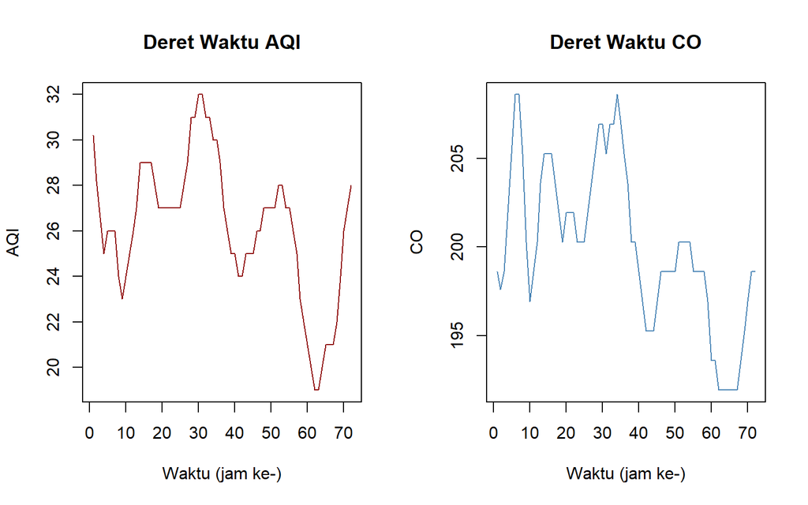

```r
par(mfrow = c(1, 2))
plot(data$Yt, type = "l", col = "darkred", ylab = "AQI", xlab = "Waktu (jam ke-)",
     main = "Deret Waktu AQI")
plot(data$Xt, type = "l", col = "steelblue", ylab = "CO", xlab = "Waktu (jam ke-)",
     main = "Deret Waktu CO")
```

## Pembagian Data Latih dan Uji

Data dibagi 80% untuk pelatihan (training) dan 20% untuk pengujian (testing) secara berurutan sesuai waktu (tidak diacak, karena data adalah deret waktu).

```r
n <- nrow(data)
n_train <- round(n * 0.8)

train <- data[1:n_train, ]
test <- data[(n_train + 1):n, ]

train.ts <- ts(train)
test.ts <- ts(test)
data.ts <- ts(data)

cat("Jumlah data latih :", nrow(train), "\n")
```

```
## Jumlah data latih : 58
```

```r
cat("Jumlah data uji    :", nrow(test), "\n")
```

```
## Jumlah data uji    : 14
```

# Model Koyck

Model Koyck mengasumsikan bobot pengaruh lag X terhadap Y menurun secara geometris, direpresentasikan melalui transformasi menjadi model autoregresif orde 1.

```r
model.koyck <- koyckDlm(x = train$Xt, y = train$Yt)
summary(model.koyck)
```

```
##
## Call:
## "Y ~ (Intercept) + Y.1 + X.t"
##
## Residuals:
##     Min      1Q  Median      3Q     Max
## -2.0594 -0.7171  0.1118  0.5371  2.2726
##
## Coefficients:
##             Estimate Std. Error t value Pr(>|t|)
## (Intercept) 1.650115   9.911979   0.166    0.868
## Y.1         0.911852   0.085460  10.670 6.55e-15 ***
## X.t         0.003086   0.056776   0.054    0.957
## ---
## Signif. codes:  0 '***' 0.001 '**' 0.01 '*' 0.05 '.' 0.1 ' ' 1
##
## Residual standard error: 0.9633 on 54 degrees of freedom
## Multiple R-Squared: 0.8139,  Adjusted R-squared: 0.807
## Wald test: 117.9 on 2 and 54 DF,  p-value: < 2.2e-16
##
## Diagnostic tests:
## NULL
##
##                             alpha        beta       phi
## Geometric coefficients:  18.71973 0.003086418 0.9118516
```

```r
fore.koyck <- forecast(model = model.koyck, x = test$Xt, h = nrow(test))
mape.koyck <- MAPE(fore.koyck$forecasts, test$Yt)
cat("MAPE Model Koyck (data uji):", mape.koyck, "\n")
```

```
## MAPE Model Koyck (data uji): 0.1370419
```

# Model DLM (Distributed Lag Model)

## Penentuan Lag Optimum

Lag optimum dicari menggunakan `finiteDLMauto()` dengan kriteria AIC, untuk rentang lag 1 sampai 10.

```r
dlm.search <- finiteDLMauto(formula = Yt ~ Xt,
                             data = data.frame(train), q.min = 1, q.max = 10,
                             model.type = "dlm", error.type = "AIC", trace = TRUE)
dlm.search
```

```
##    q - k    MASE      AIC      BIC    GMRAE    MBRAE R.Adj.Sq    Ljung-Box
## 10    10 0.90515 136.4032 160.7288 26818.33  0.54874  0.83325 1.081157e-03
## 9      9 0.92035 137.9987 160.7005 20924.03  0.48557  0.83917 1.442401e-03
## 8      8 1.06658 156.8234 177.8556 18837.93  0.05585  0.78656 1.590823e-02
## 7      7 1.33336 180.5029 199.8212 20418.70  0.06402  0.68114 3.046921e-03
## 6      6 1.46633 197.7025 215.2637 17811.92 -3.45588  0.57122 3.703213e-05
## 5      5 1.65291 210.1633 225.9257 21457.68  0.13138  0.47804 1.537231e-07
## 4      4 1.84421 216.5591 230.4820 34360.90  2.18078  0.43568 1.081398e-08
## 3      3 1.93920 220.8850 232.9289 32422.79  0.57923  0.42049 4.434820e-10
## 2      2 1.84853 221.9900 232.1167 25647.88  0.14415  0.42972 1.024816e-09
## 1      1 1.83815 225.7193 233.8915 20586.68  1.86318  0.41390 2.330515e-09
```

Lag optimum berdasarkan AIC terkecil adalah **q = 10**.

```r
q_dlm_opt <- dlm.search[which.min(dlm.search$AIC), "q - k"]

model.dlm.opt <- dlm(x = train$Xt, y = train$Yt, q = q_dlm_opt)
summary(model.dlm.opt)
```

```
##
## Call:
## lm(formula = model.formula, data = design)
##
## Residuals:
##      Min       1Q   Median       3Q      Max
## -2.98455 -0.33973  0.08105  0.39374  2.07432
##
## Coefficients:
##              Estimate Std. Error t value Pr(>|t|)
## (Intercept) -58.80864   12.01631  -4.894 2.08e-05 ***
## x.t           0.49080    0.11521   4.260  0.00014 ***
## x.1           0.14926    0.18074   0.826  0.41433
## x.2          -0.12857    0.18077  -0.711  0.48153
## x.3           0.15065    0.18886   0.798  0.43029
## x.4          -0.02252    0.18919  -0.119  0.90590
## x.5          -0.24536    0.19553  -1.255  0.21763
## x.6           0.12244    0.19188   0.638  0.52744
## x.7          -0.04624    0.19028  -0.243  0.80936
## x.8          -0.06643    0.18143  -0.366  0.71642
## x.9          -0.04978    0.17985  -0.277  0.78355
## x.10          0.07431    0.10354   0.718  0.47756
## ---
## Signif. codes:  0 '***' 0.001 '**' 0.01 '*' 0.05 '.' 0.1 ' ' 1
##
## Residual standard error: 0.8824 on 36 degrees of freedom
## Multiple R-squared:  0.8723, Adjusted R-squared:  0.8332
## F-statistic: 22.35 on 11 and 36 DF,  p-value: 7.332e-13
##
## AIC and BIC values for the model:
##        AIC      BIC
## 1 136.4032 160.7288
```

```r
fore.dlm.opt <- forecast(model = model.dlm.opt, x = test$Xt, h = nrow(test))
mape.dlm.opt <- MAPE(fore.dlm.opt$forecasts, test$Yt)
cat("MAPE Model DLM Optimum (q =", q_dlm_opt, "):", mape.dlm.opt, "\n")
```

```
## MAPE Model DLM Optimum (q = 10 ): 0.1005581
```

# Model ARDL (Autoregressive Distributed Lag)

## Penentuan Orde Lag Optimum

Kombinasi lag X (p) dan lag Y (q) dicari menggunakan `ardlBoundOrders()` dengan kriteria AIC. Batas maksimum lag ditetapkan p = 6 dan q = 6 agar proporsional terhadap jumlah data latih (58 observasi).

```r
model.ardl.search <- ardlBoundOrders(data = data.frame(train), ic = "AIC",
                                      formula = Yt ~ Xt, max.p = 6, max.q = 6)

min_p <- c()
for (i in 1:6) {
  min_p[i] <- min(model.ardl.search$Stat.table[[i]])
}
q_opt <- which(min_p == min(min_p, na.rm = TRUE))
p_opt <- which(model.ardl.search$Stat.table[[q_opt]] ==
                 min(model.ardl.search$Stat.table[[q_opt]], na.rm = TRUE))

data.frame("Lag_Y_opt(q)" = q_opt, "Lag_X_opt(p)" = p_opt,
           "AIC" = model.ardl.search$min.Stat)
```

```
##   Lag_Y_opt.q. Lag_X_opt.p.     AIC
## 1            1            6 117.422
```

Orde optimum yang terpilih adalah **ARDL(p = 6, q = 1)**.

```r
model.ardl <- ardlDlm(formula = Yt ~ Xt, data = train, p = p_opt, q = q_opt)
summary(model.ardl)
```

```
##
## Time series regression with "ts" data:
## Start = 7, End = 58
##
## Call:
## dynlm(formula = as.formula(model.text), data = data)
##
## Residuals:
##      Min       1Q   Median       3Q      Max
## -2.05466 -0.32436 -0.09088  0.36214  1.81021
##
## Coefficients:
##             Estimate Std. Error t value Pr(>|t|)
## (Intercept) -0.99873    9.77838  -0.102   0.9191
## Xt.t         0.27515    0.10458   2.631   0.0118 *
## Xt.1        -0.09523    0.15268  -0.624   0.5361
## Xt.2        -0.34860    0.14758  -2.362   0.0228 *
## Xt.3         0.26272    0.15627   1.681   0.1000 .
## Xt.4         0.03437    0.14826   0.232   0.8178
## Xt.5        -0.26019    0.15322  -1.698   0.0967 .
## Xt.6         0.15113    0.08915   1.695   0.0973 .
## Yt.1         0.89335    0.08254  10.824  7.4e-14 ***
## ---
## Signif. codes:  0 '***' 0.001 '**' 0.01 '*' 0.05 '.' 0.1 ' ' 1
##
## Residual standard error: 0.7761 on 43 degrees of freedom
## Multiple R-squared:  0.9007, Adjusted R-squared:  0.8822
## F-statistic: 48.74 on 8 and 43 DF,  p-value: < 2.2e-16
```

```r
fore.ardl <- forecast(model = model.ardl, x = test$Xt, h = nrow(test))
mape.ardl <- MAPE(fore.ardl$forecasts, test$Yt)
cat("MAPE Model ARDL (", p_opt, ",", q_opt, "):", mape.ardl, "\n")
```

```
## MAPE Model ARDL ( 6 , 1 ): 0.09710131
```

# Evaluasi Asumsi Model

Evaluasi asumsi klasik (non-autokorelasi, homoskedastisitas, dan normalitas residual) dilakukan pada representasi `lm`/`dynlm` dari masing-masing model. Untuk model Koyck (yang diestimasi dengan IV pada `dLagM`), digunakan model `dynlm` padanan Y[t] ~ X[t] + Y[t-1] sebagai representasi diagnostik, sesuai struktur Koyck.

```r
lm.koyck_diag <- dynlm(Yt ~ Xt + L(Yt), data = train.ts)
```

## Uji Autokorelasi (Durbin-Watson)

```r
dwtest(lm.koyck_diag)
```

```
##
##  Durbin-Watson test
##
## data:  lm.koyck_diag
## DW = 0.97648, p-value = 5.297e-06
## alternative hypothesis: true autocorrelation is greater than 0
```

```r
dwtest(model.dlm.opt$model)
```

```
##
##  Durbin-Watson test
##
## data:  model.dlm.opt$model
## DW = 0.76692, p-value = 1.306e-06
## alternative hypothesis: true autocorrelation is greater than 0
```

```r
dwtest(model.ardl$model)
```

```
##
##  Durbin-Watson test
##
## data:  model.ardl$model
## DW = 1.3229, p-value = 0.002513
## alternative hypothesis: true autocorrelation is greater than 0
```

## Uji Homoskedastisitas (Breusch-Pagan)

```r
bptest(lm.koyck_diag)
```

```
##
##  studentized Breusch-Pagan test
##
## data:  lm.koyck_diag
## BP = 3.2803, df = 2, p-value = 0.1939
```

```r
bptest(model.dlm.opt$model)
```

```
##
##  studentized Breusch-Pagan test
##
## data:  model.dlm.opt$model
## BP = 4.868, df = 11, p-value = 0.9374
```

```r
bptest(model.ardl$model)
```

```
##
##  studentized Breusch-Pagan test
##
## data:  model.ardl$model
## BP = 4.66, df = 8, p-value = 0.7932
```

## Uji Normalitas Residual (Shapiro-Wilk)

```r
shapiro.test(residuals(lm.koyck_diag))
```

```
##
##  Shapiro-Wilk normality test
##
## data:  residuals(lm.koyck_diag)
## W = 0.97524, p-value = 0.2911
```

```r
shapiro.test(residuals(model.dlm.opt$model))
```

```
##
##  Shapiro-Wilk normality test
##
## data:  residuals(model.dlm.opt$model)
## W = 0.92698, p-value = 0.005287
```

```r
shapiro.test(residuals(model.ardl$model))
```

```
##
##  Shapiro-Wilk normality test
##
## data:  residuals(model.ardl$model)
## W = 0.97409, p-value = 0.3125
```

Ketiga model menunjukkan autokorelasi residual positif yang signifikan (DW < 2, p-value < 0.05), meskipun sudah memasukkan struktur lag. Ini mengindikasikan masih ada pola perubahan dari waktu ke waktu yang belum tertangkap sepenuhnya (misalnya pengaruh polutan lain atau faktor meteorologi yang tidak dimodelkan). Asumsi homoskedastisitas terpenuhi pada ketiga model (Breusch-Pagan p-value > 0.05). Asumsi normalitas residual terpenuhi pada model Koyck dan ARDL, namun tidak terpenuhi pada model DLM optimum (Shapiro-Wilk p-value < 0.05), kemungkinan akibat lag orde tinggi (q = 10) yang menyisakan sedikit derajat bebas relatif terhadap jumlah parameter.

# Perbandingan Kinerja Model

## Metrik Akurasi (MAPE) dan Deviance

Deviance dihitung sebagai jumlah kuadrat residual (RSS) pada data latih.

```r
deviance.koyck <- sum(residuals(model.koyck$model)^2)
deviance.dlm <- deviance(model.dlm.opt$model)
deviance.ardl <- deviance(model.ardl$model)

akurasi <- data.frame(
  Model = c("Koyck", paste0("DLM (q=", q_dlm_opt, ")"),
            paste0("ARDL (p=", p_opt, ", q=", q_opt, ")")),
  MAPE = c(mape.koyck, mape.dlm.opt, mape.ardl),
  Deviance = c(deviance.koyck, deviance.dlm, deviance.ardl)
)
akurasi
```

```
##             Model       MAPE Deviance
## 1           Koyck 0.13704186 50.10675
## 2      DLM (q=10) 0.10055807 28.03320
## 3 ARDL (p=6, q=1) 0.09710131 25.90052
```

Model **ARDL(6, 1)** memberikan MAPE data uji terkecil sekaligus deviance (RSS) data latih terkecil, sehingga menjadi model dengan kinerja peramalan terbaik di antara ketiga metode pada kasus ini. Hal ini masuk akal secara konseptual, karena ARDL adalah model paling fleksibel yang mencakup struktur DLM (lag pada X) sekaligus struktur autoregresif (lag pada Y) secara bersamaan.

## Visualisasi Perbandingan Peramalan

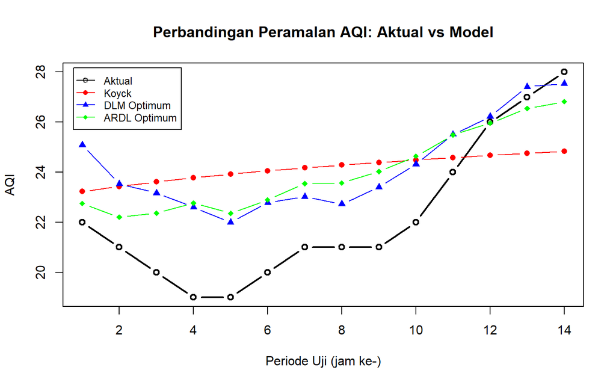

```r
par(mfrow = c(1, 1))
plot(1:nrow(test), test$Yt, type = "b", col = "black", lwd = 2, pch = 1,
     ylim = range(c(test$Yt, fore.koyck$forecasts, fore.dlm.opt$forecasts,
                     fore.ardl$forecasts)),
     ylab = "AQI", xlab = "Periode Uji (jam ke-)",
     main = "Perbandingan Peramalan AQI: Aktual vs Model")

lines(1:nrow(test), fore.koyck$forecasts, col = "red", type = "b", pch = 16)
lines(1:nrow(test), fore.dlm.opt$forecasts, col = "blue", type = "b", pch = 17)
lines(1:nrow(test), fore.ardl$forecasts, col = "green", type = "b", pch = 18)

legend("topleft", legend = c("Aktual", "Koyck", "DLM Optimum", "ARDL Optimum"),
       col = c("black", "red", "blue", "green"), lty = 1,
       pch = c(1, 16, 17, 18), cex = 0.8, inset = 0.02)
```

# Kesimpulan

1. Ketiga metode regresi peubah lag (Koyck, DLM, dan ARDL) berhasil diterapkan pada data AQI dan CO New Delhi dengan lag optimum yang berbeda: Koyck (struktur AR(1) bawaan), DLM dengan q = 10, dan ARDL dengan p = 6, q = 1.
2. Model **ARDL** memberikan kinerja peramalan terbaik (MAPE dan deviance terkecil), karena mengombinasikan efek lag dari X dan Y sekaligus.
3. Autokorelasi residual masih terdeteksi pada ketiga model, menunjukkan perlunya eksplorasi lanjutan (misalnya menambahkan peubah polutan lain atau faktor meteorologi, atau menggunakan model ARDL berganda) untuk penelitian lebih lanjut.